# Risk Factor Analysis

## Outcome Variable

**Outcome Variable:** stunted

## Predictor Variables

**Intervention Variable:** mbmi

**Adjustment Set:**

- arm
- W_mage
- meducyrs
- feducyrs
- hhwealth_quart
- brthmon
- W_parity
- impfloor
- impsan
- safeh20
- delta_W_mage
- delta_meducyrs
- delta_feducyrs
- delta_hhwealth_quart
- delta_brthmon
- delta_W_parity
- delta_impfloor
- delta_impsan
- delta_safeh20

## Stratifying Variables

The analysis was stratified on these variable(s):

- agecat
- studyid
- country

## Data Summary

| agecat | studyid | country | mbmi | stunted | n_cell | n |
| --- | --- | --- | --- | --- | --- | --- |
| Birth | ki0047075b-MAL-ED | BANGLADESH | Normal weight | 0 | 159 | 222 |
| Birth | ki0047075b-MAL-ED | BANGLADESH | Normal weight | 1 | 35 | 222 |
| Birth | ki0047075b-MAL-ED | BANGLADESH | Underweight | 0 | 23 | 222 |
| Birth | ki0047075b-MAL-ED | BANGLADESH | Underweight | 1 | 5 | 222 |
| Birth | ki0047075b-MAL-ED | BRAZIL | Normal weight | 0 | 52 | 64 |
| Birth | ki0047075b-MAL-ED | BRAZIL | Normal weight | 1 | 7 | 64 |
| Birth | ki0047075b-MAL-ED | BRAZIL | Underweight | 0 | 3 | 64 |
| Birth | ki0047075b-MAL-ED | BRAZIL | Underweight | 1 | 2 | 64 |
| Birth | ki0047075b-MAL-ED | INDIA | Normal weight | 0 | 27 | 43 |
| Birth | ki0047075b-MAL-ED | INDIA | Normal weight | 1 | 8 | 43 |
| Birth | ki0047075b-MAL-ED | INDIA | Underweight | 0 | 7 | 43 |
| Birth | ki0047075b-MAL-ED | INDIA | Underweight | 1 | 1 | 43 |
| Birth | ki0047075b-MAL-ED | NEPAL | Normal weight | 0 | 25 | 27 |
| Birth | ki0047075b-MAL-ED | NEPAL | Normal weight | 1 | 2 | 27 |
| Birth | ki0047075b-MAL-ED | NEPAL | Underweight | 0 | 0 | 27 |
| Birth | ki0047075b-MAL-ED | NEPAL | Underweight | 1 | 0 | 27 |
| Birth | ki0047075b-MAL-ED | PERU | Normal weight | 0 | 197 | 226 |
| Birth | ki0047075b-MAL-ED | PERU | Normal weight | 1 | 24 | 226 |
| Birth | ki0047075b-MAL-ED | PERU | Underweight | 0 | 3 | 226 |
| Birth | ki0047075b-MAL-ED | PERU | Underweight | 1 | 2 | 226 |
| Birth | ki0047075b-MAL-ED | SOUTH AFRICA | Normal weight | 0 | 89 | 101 |
| Birth | ki0047075b-MAL-ED | SOUTH AFRICA | Normal weight | 1 | 9 | 101 |
| Birth | ki0047075b-MAL-ED | SOUTH AFRICA | Underweight | 0 | 3 | 101 |
| Birth | ki0047075b-MAL-ED | SOUTH AFRICA | Underweight | 1 | 0 | 101 |
| Birth | ki0047075b-MAL-ED | TANZANIA, UNITED REPUBLIC OF | Normal weight | 0 | 96 | 122 |
| Birth | ki0047075b-MAL-ED | TANZANIA, UNITED REPUBLIC OF | Normal weight | 1 | 19 | 122 |
| Birth | ki0047075b-MAL-ED | TANZANIA, UNITED REPUBLIC OF | Underweight | 0 | 4 | 122 |
| Birth | ki0047075b-MAL-ED | TANZANIA, UNITED REPUBLIC OF | Underweight | 1 | 3 | 122 |
| Birth | ki1000304b-SAS-CompFeed | INDIA | Normal weight | 0 | 615 | 1135 |
| Birth | ki1000304b-SAS-CompFeed | INDIA | Normal weight | 1 | 215 | 1135 |

[output cut: 150 more lines]

The following strata were considered:

- agecat: 24 months, studyid: ki0047075b-MAL-ED, country: BANGLADESH
- agecat: 24 months, studyid: ki0047075b-MAL-ED, country: BRAZIL
- agecat: 24 months, studyid: ki0047075b-MAL-ED, country: INDIA
- agecat: 24 months, studyid: ki0047075b-MAL-ED, country: NEPAL
- agecat: 24 months, studyid: ki0047075b-MAL-ED, country: PERU
- agecat: 24 months, studyid: ki0047075b-MAL-ED, country: SOUTH AFRICA
- agecat: 24 months, studyid: ki0047075b-MAL-ED, country: TANZANIA, UNITED REPUBLIC OF
- agecat: 24 months, studyid: ki1017093-NIH-Birth, country: BANGLADESH
- agecat: 24 months, studyid: ki1017093b-PROVIDE, country: BANGLADESH
- agecat: 24 months, studyid: ki1017093c-NIH-Crypto, country: BANGLADESH
- agecat: 24 months, studyid: ki1066203-TanzaniaChild2, country: TANZANIA, UNITED REPUBLIC OF
- agecat: 24 months, studyid: ki1119695-PROBIT, country: BELARUS
- agecat: 24 months, studyid: ki1126311-ZVITAMBO, country: ZIMBABWE
- agecat: 24 months, studyid: ki1148112-LCNI-5, country: MALAWI
- agecat: 24 months, studyid: kiGH5241-JiVitA-3, country: BANGLADESH
- agecat: 6 months, studyid: ki0047075b-MAL-ED, country: BANGLADESH
- agecat: 6 months, studyid: ki0047075b-MAL-ED, country: BRAZIL
- agecat: 6 months, studyid: ki0047075b-MAL-ED, country: INDIA
- agecat: 6 months, studyid: ki0047075b-MAL-ED, country: NEPAL
- agecat: 6 months, studyid: ki0047075b-MAL-ED, country: PERU
- agecat: 6 months, studyid: ki0047075b-MAL-ED, country: SOUTH AFRICA
- agecat: 6 months, studyid: ki0047075b-MAL-ED, country: TANZANIA, UNITED REPUBLIC OF
- agecat: 6 months, studyid: ki1000304b-SAS-CompFeed, country: INDIA
- agecat: 6 months, studyid: ki1017093-NIH-Birth, country: BANGLADESH
- agecat: 6 months, studyid: ki1017093b-PROVIDE, country: BANGLADESH
- agecat: 6 months, studyid: ki1017093c-NIH-Crypto, country: BANGLADESH
- agecat: 6 months, studyid: ki1066203-TanzaniaChild2, country: TANZANIA, UNITED REPUBLIC OF
- agecat: 6 months, studyid: ki1119695-PROBIT, country: BELARUS
- agecat: 6 months, studyid: ki1126311-ZVITAMBO, country: ZIMBABWE
- agecat: 6 months, studyid: ki1148112-LCNI-5, country: MALAWI
- agecat: 6 months, studyid: kiGH5241-JiVitA-3, country: BANGLADESH
- agecat: Birth, studyid: ki0047075b-MAL-ED, country: BANGLADESH
- agecat: Birth, studyid: ki0047075b-MAL-ED, country: BRAZIL
- agecat: Birth, studyid: ki0047075b-MAL-ED, country: INDIA
- agecat: Birth, studyid: ki0047075b-MAL-ED, country: NEPAL
- agecat: Birth, studyid: ki0047075b-MAL-ED, country: PERU
- agecat: Birth, studyid: ki0047075b-MAL-ED, country: SOUTH AFRICA
- agecat: Birth, studyid: ki0047075b-MAL-ED, country: TANZANIA, UNITED REPUBLIC OF
- agecat: Birth, studyid: ki1000304b-SAS-CompFeed, country: INDIA
- agecat: Birth, studyid: ki1017093-NIH-Birth, country: BANGLADESH
- agecat: Birth, studyid: ki1017093b-PROVIDE, country: BANGLADESH
- agecat: Birth, studyid: ki1017093c-NIH-Crypto, country: BANGLADESH
- agecat: Birth, studyid: ki1119695-PROBIT, country: BELARUS
- agecat: Birth, studyid: ki1126311-ZVITAMBO, country: ZIMBABWE
- agecat: Birth, studyid: kiGH5241-JiVitA-3, country: BANGLADESH

### Dropped Strata

Some strata were dropped due to rare outcomes:

- agecat: Birth, studyid: ki0047075b-MAL-ED, country: BRAZIL
- agecat: Birth, studyid: ki0047075b-MAL-ED, country: INDIA
- agecat: Birth, studyid: ki0047075b-MAL-ED, country: NEPAL
- agecat: Birth, studyid: ki0047075b-MAL-ED, country: PERU
- agecat: Birth, studyid: ki0047075b-MAL-ED, country: SOUTH AFRICA
- agecat: Birth, studyid: ki0047075b-MAL-ED, country: TANZANIA, UNITED REPUBLIC OF
- agecat: Birth, studyid: ki1119695-PROBIT, country: BELARUS
- agecat: 6 months, studyid: ki0047075b-MAL-ED, country: BRAZIL
- agecat: 6 months, studyid: ki0047075b-MAL-ED, country: NEPAL
- agecat: 6 months, studyid: ki0047075b-MAL-ED, country: PERU
- agecat: 6 months, studyid: ki0047075b-MAL-ED, country: SOUTH AFRICA
- agecat: 6 months, studyid: ki0047075b-MAL-ED, country: TANZANIA, UNITED REPUBLIC OF
- agecat: 6 months, studyid: ki1066203-TanzaniaChild2, country: TANZANIA, UNITED REPUBLIC OF
- agecat: 24 months, studyid: ki0047075b-MAL-ED, country: BRAZIL
- agecat: 24 months, studyid: ki0047075b-MAL-ED, country: NEPAL
- agecat: 24 months, studyid: ki0047075b-MAL-ED, country: PERU
- agecat: 24 months, studyid: ki0047075b-MAL-ED, country: SOUTH AFRICA
- agecat: 24 months, studyid: ki0047075b-MAL-ED, country: TANZANIA, UNITED REPUBLIC OF
- agecat: 24 months, studyid: ki1066203-TanzaniaChild2, country: TANZANIA, UNITED REPUBLIC OF

## Methods Detail

We’re interested in the causal parameters $E[Y_a]$ for all values of $a \in \mathcal{A}$. These parameters represent the mean outcome if, possibly contrary to fact, we intervened to set all units to have $A=a$. Under the randomization and positivity assumptions, these are identified by the statistical parameters $\psi_a=E_W[E_{Y|A,W}(Y|A=a,W)]$. In addition, we’re interested in the mean of $Y$, $E[Y]$ under no intervention (the observed mean). We will estimate these parameters by using SuperLearner to fit the relevant likelihood factors – $E_{Y|A,W}(Y|A=a,W)$ and $p(A=a|W)$, and then updating our likelihood fit using a joint TMLE.

For unadjusted analyses ($W=\{\}$), initial likelihoods were estimated using Lrnr_glm to estimate the simple $E(Y|A)$ and Lrnr_mean to estimate $p(A)$. For adjusted analyses, a small library containing Lrnr_glmnet, Lrnr_xgboost, and Lrnr_mean was used.

Having estimated these parameters, we will then use the delta method to estimate relative risks and attributable risks relative to a prespecified baseline level of $A$.

# Results Detail

## Results Plots

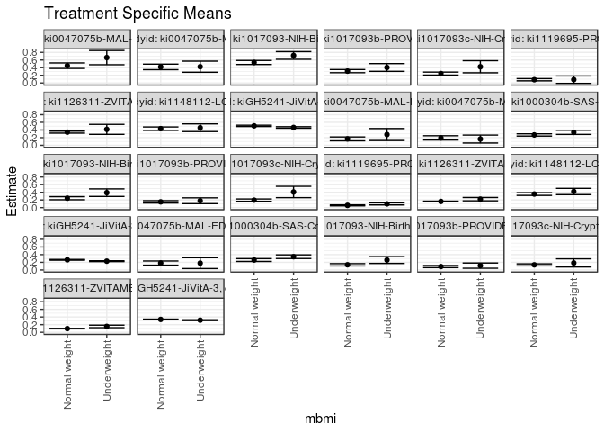

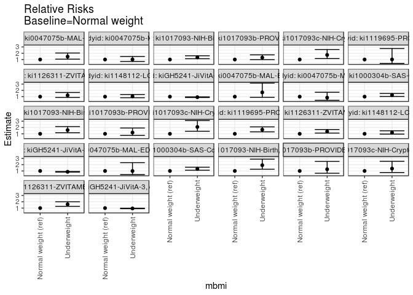

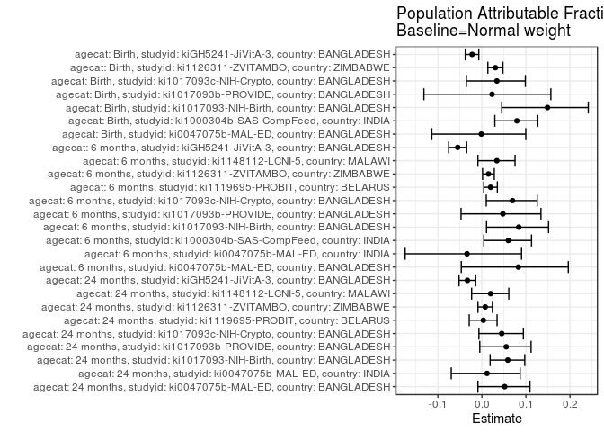

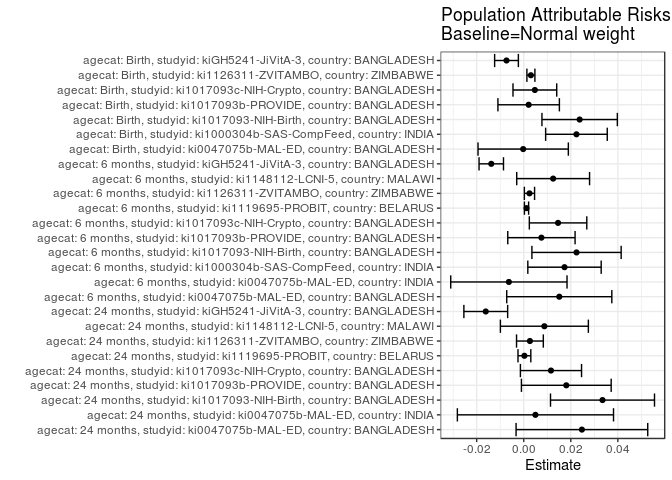

## Results Table

### Parameter: TSM

| agecat | studyid | country | intervention_level | baseline_level | estimate | ci_lower | ci_upper |
| --- | --- | --- | --- | --- | --- | --- | --- |
| Birth | ki0047075b-MAL-ED | BANGLADESH | Normal weight | NA | 0.1804124 | 0.1261800 | 0.2346447 |
| Birth | ki0047075b-MAL-ED | BANGLADESH | Underweight | NA | 0.1785714 | 0.0363908 | 0.3207520 |
| Birth | ki1000304b-SAS-CompFeed | INDIA | Normal weight | NA | 0.2595324 | 0.2227251 | 0.2963397 |
| Birth | ki1000304b-SAS-CompFeed | INDIA | Underweight | NA | 0.3460427 | 0.2981489 | 0.3939365 |
| Birth | ki1017093-NIH-Birth | BANGLADESH | Normal weight | NA | 0.1357711 | 0.1058070 | 0.1657351 |
| Birth | ki1017093-NIH-Birth | BANGLADESH | Underweight | NA | 0.2596646 | 0.1709502 | 0.3483790 |
| Birth | ki1017093b-PROVIDE | BANGLADESH | Normal weight | NA | 0.0888140 | 0.0611795 | 0.1164485 |
| Birth | ki1017093b-PROVIDE | BANGLADESH | Underweight | NA | 0.1130112 | 0.0440904 | 0.1819321 |
| Birth | ki1017093c-NIH-Crypto | BANGLADESH | Normal weight | NA | 0.1338186 | 0.1076990 | 0.1599382 |
| Birth | ki1017093c-NIH-Crypto | BANGLADESH | Underweight | NA | 0.1840742 | 0.0777231 | 0.2904252 |
| Birth | ki1126311-ZVITAMBO | ZIMBABWE | Normal weight | NA | 0.0958981 | 0.0898665 | 0.1019297 |
| Birth | ki1126311-ZVITAMBO | ZIMBABWE | Underweight | NA | 0.1533170 | 0.1205509 | 0.1860831 |
| Birth | kiGH5241-JiVitA-3 | BANGLADESH | Normal weight | NA | 0.3361521 | 0.3271370 | 0.3451672 |
| Birth | kiGH5241-JiVitA-3 | BANGLADESH | Underweight | NA | 0.3171588 | 0.3063344 | 0.3279831 |
| 6 months | ki0047075b-MAL-ED | BANGLADESH | Normal weight | NA | 0.1674641 | 0.1167370 | 0.2181912 |
| 6 months | ki0047075b-MAL-ED | BANGLADESH | Underweight | NA | 0.2812500 | 0.1251470 | 0.4373530 |
| 6 months | ki0047075b-MAL-ED | INDIA | Normal weight | NA | 0.1935484 | 0.1366498 | 0.2504470 |
| 6 months | ki0047075b-MAL-ED | INDIA | Underweight | NA | 0.1632653 | 0.0595562 | 0.2669744 |
| 6 months | ki1000304b-SAS-CompFeed | INDIA | Normal weight | NA | 0.2709438 | 0.2412732 | 0.3006144 |
| 6 months | ki1000304b-SAS-CompFeed | INDIA | Underweight | NA | 0.3386727 | 0.2846344 | 0.3927111 |
| 6 months | ki1017093-NIH-Birth | BANGLADESH | Normal weight | NA | 0.2457136 | 0.2056004 | 0.2858268 |
| 6 months | ki1017093-NIH-Birth | BANGLADESH | Underweight | NA | 0.3904707 | 0.2915867 | 0.4893546 |
| 6 months | ki1017093b-PROVIDE | BANGLADESH | Normal weight | NA | 0.1500248 | 0.1185426 | 0.1815070 |
| 6 months | ki1017093b-PROVIDE | BANGLADESH | Underweight | NA | 0.1793448 | 0.1030715 | 0.2556180 |
| 6 months | ki1017093c-NIH-Crypto | BANGLADESH | Normal weight | NA | 0.1951982 | 0.1643836 | 0.2260128 |
| 6 months | ki1017093c-NIH-Crypto | BANGLADESH | Underweight | NA | 0.4079498 | 0.2597821 | 0.5561175 |
| 6 months | ki1119695-PROBIT | BELARUS | Normal weight | NA | 0.0586900 | 0.0458502 | 0.0715299 |
| 6 months | ki1119695-PROBIT | BELARUS | Underweight | NA | 0.0974568 | 0.0694085 | 0.1255051 |
| 6 months | ki1126311-ZVITAMBO | ZIMBABWE | Normal weight | NA | 0.1606803 | 0.1520683 | 0.1692922 |
| 6 months | ki1126311-ZVITAMBO | ZIMBABWE | Underweight | NA | 0.2205595 | 0.1767638 | 0.2643551 |
| 6 months | ki1148112-LCNI-5 | MALAWI | Normal weight | NA | 0.3547232 | 0.3189759 | 0.3904705 |
| 6 months | ki1148112-LCNI-5 | MALAWI | Underweight | NA | 0.4211358 | 0.3392462 | 0.5030254 |
| 6 months | kiGH5241-JiVitA-3 | BANGLADESH | Normal weight | NA | 0.2653464 | 0.2551537 | 0.2755391 |
| 6 months | kiGH5241-JiVitA-3 | BANGLADESH | Underweight | NA | 0.2296890 | 0.2188098 | 0.2405683 |
| 24 months | ki0047075b-MAL-ED | BANGLADESH | Normal weight | NA | 0.4516868 | 0.3791969 | 0.5241767 |
| 24 months | ki0047075b-MAL-ED | BANGLADESH | Underweight | NA | 0.6630111 | 0.4767576 | 0.8492646 |
| 24 months | ki0047075b-MAL-ED | INDIA | Normal weight | NA | 0.4198015 | 0.3472654 | 0.4923376 |
| 24 months | ki0047075b-MAL-ED | INDIA | Underweight | NA | 0.4248345 | 0.2797183 | 0.5699506 |
| 24 months | ki1017093-NIH-Birth | BANGLADESH | Normal weight | NA | 0.5352818 | 0.4828730 | 0.5876906 |
| 24 months | ki1017093-NIH-Birth | BANGLADESH | Underweight | NA | 0.7188744 | 0.6183493 | 0.8193996 |
| 24 months | ki1017093b-PROVIDE | BANGLADESH | Normal weight | NA | 0.3094613 | 0.2676549 | 0.3512677 |
| 24 months | ki1017093b-PROVIDE | BANGLADESH | Underweight | NA | 0.4051100 | 0.3035778 | 0.5066422 |
| 24 months | ki1017093c-NIH-Crypto | BANGLADESH | Normal weight | NA | 0.2452270 | 0.2062943 | 0.2841596 |
| 24 months | ki1017093c-NIH-Crypto | BANGLADESH | Underweight | NA | 0.4236013 | 0.2657297 | 0.5814729 |
| 24 months | ki1119695-PROBIT | BELARUS | Normal weight | NA | 0.0851057 | 0.0556379 | 0.1145735 |
| 24 months | ki1119695-PROBIT | BELARUS | Underweight | NA | 0.0858664 | -0.0113138 | 0.1830466 |
| 24 months | ki1126311-ZVITAMBO | ZIMBABWE | Normal weight | NA | 0.3440523 | 0.3183069 | 0.3697976 |
| 24 months | ki1126311-ZVITAMBO | ZIMBABWE | Underweight | NA | 0.4163009 | 0.2865372 | 0.5460646 |
| 24 months | ki1148112-LCNI-5 | MALAWI | Normal weight | NA | 0.4348975 | 0.3903480 | 0.4794470 |
| 24 months | ki1148112-LCNI-5 | MALAWI | Underweight | NA | 0.4585987 | 0.3582001 | 0.5589972 |
| 24 months | kiGH5241-JiVitA-3 | BANGLADESH | Normal weight | NA | 0.5075894 | 0.4910461 | 0.5241326 |
| 24 months | kiGH5241-JiVitA-3 | BANGLADESH | Underweight | NA | 0.4655059 | 0.4463484 | 0.4846634 |

### Parameter: E(Y)

| agecat | studyid | country | intervention_level | baseline_level | estimate | ci_lower | ci_upper |
| --- | --- | --- | --- | --- | --- | --- | --- |
| Birth | ki0047075b-MAL-ED | BANGLADESH | NA | NA | 0.1801802 | 0.1295086 | 0.2308518 |
| Birth | ki1000304b-SAS-CompFeed | INDIA | NA | NA | 0.2819383 | 0.2495848 | 0.3142918 |
| Birth | ki1017093-NIH-Birth | BANGLADESH | NA | NA | 0.1595395 | 0.1304091 | 0.1886699 |
| Birth | ki1017093b-PROVIDE | BANGLADESH | NA | NA | 0.0909091 | 0.0661046 | 0.1157136 |
| Birth | ki1017093c-NIH-Crypto | BANGLADESH | NA | NA | 0.1385460 | 0.1134505 | 0.1636414 |
| Birth | ki1126311-ZVITAMBO | ZIMBABWE | NA | NA | 0.0989454 | 0.0929945 | 0.1048964 |
| Birth | kiGH5241-JiVitA-3 | BANGLADESH | NA | NA | 0.3288302 | 0.3214550 | 0.3362055 |
| 6 months | ki0047075b-MAL-ED | BANGLADESH | NA | NA | 0.1825726 | 0.1336978 | 0.2314474 |
| 6 months | ki0047075b-MAL-ED | INDIA | NA | NA | 0.1872340 | 0.1372518 | 0.2372162 |
| 6 months | ki1000304b-SAS-CompFeed | INDIA | NA | NA | 0.2882736 | 0.2624662 | 0.3140810 |
| 6 months | ki1017093-NIH-Birth | BANGLADESH | NA | NA | 0.2681564 | 0.2306532 | 0.3056597 |
| 6 months | ki1017093b-PROVIDE | BANGLADESH | NA | NA | 0.1575456 | 0.1284434 | 0.1866478 |
| 6 months | ki1017093c-NIH-Crypto | BANGLADESH | NA | NA | 0.2097902 | 0.1799252 | 0.2396552 |
| 6 months | ki1119695-PROBIT | BELARUS | NA | NA | 0.0598756 | 0.0470544 | 0.0726968 |
| 6 months | ki1126311-ZVITAMBO | ZIMBABWE | NA | NA | 0.1631186 | 0.1546857 | 0.1715516 |
| 6 months | ki1148112-LCNI-5 | MALAWI | NA | NA | 0.3672249 | 0.3345288 | 0.3999210 |
| 6 months | kiGH5241-JiVitA-3 | BANGLADESH | NA | NA | 0.2515513 | 0.2434364 | 0.2596662 |
| 24 months | ki0047075b-MAL-ED | BANGLADESH | NA | NA | 0.4764151 | 0.4090254 | 0.5438047 |
| 24 months | ki0047075b-MAL-ED | INDIA | NA | NA | 0.4247788 | 0.3601902 | 0.4893673 |
| 24 months | ki1017093-NIH-Birth | BANGLADESH | NA | NA | 0.5687646 | 0.5218455 | 0.6156837 |
| 24 months | ki1017093b-PROVIDE | BANGLADESH | NA | NA | 0.3275563 | 0.2892291 | 0.3658836 |
| 24 months | ki1017093c-NIH-Crypto | BANGLADESH | NA | NA | 0.2568093 | 0.2190047 | 0.2946140 |
| 24 months | ki1119695-PROBIT | BELARUS | NA | NA | 0.0853933 | 0.0554084 | 0.1153781 |
| 24 months | ki1126311-ZVITAMBO | ZIMBABWE | NA | NA | 0.3466861 | 0.3215035 | 0.3718687 |
| 24 months | ki1148112-LCNI-5 | MALAWI | NA | NA | 0.4436742 | 0.4031015 | 0.4842468 |
| 24 months | kiGH5241-JiVitA-3 | BANGLADESH | NA | NA | 0.4914525 | 0.4783104 | 0.5045946 |

### Parameter: RR

| agecat | studyid | country | intervention_level | baseline_level | estimate | ci_lower | ci_upper |
| --- | --- | --- | --- | --- | --- | --- | --- |
| Birth | ki0047075b-MAL-ED | BANGLADESH | Normal weight | Normal weight | 1.0000000 | 1.0000000 | 1.0000000 |
| Birth | ki0047075b-MAL-ED | BANGLADESH | Underweight | Normal weight | 0.9897959 | 0.4226026 | 2.3182439 |
| Birth | ki1000304b-SAS-CompFeed | INDIA | Normal weight | Normal weight | 1.0000000 | 1.0000000 | 1.0000000 |
| Birth | ki1000304b-SAS-CompFeed | INDIA | Underweight | Normal weight | 1.3333314 | 1.1170784 | 1.5914484 |
| Birth | ki1017093-NIH-Birth | BANGLADESH | Normal weight | Normal weight | 1.0000000 | 1.0000000 | 1.0000000 |
| Birth | ki1017093-NIH-Birth | BANGLADESH | Underweight | Normal weight | 1.9125180 | 1.2727814 | 2.8738048 |
| Birth | ki1017093b-PROVIDE | BANGLADESH | Normal weight | Normal weight | 1.0000000 | 1.0000000 | 1.0000000 |
| Birth | ki1017093b-PROVIDE | BANGLADESH | Underweight | Normal weight | 1.2724481 | 0.6416243 | 2.5234771 |
| Birth | ki1017093c-NIH-Crypto | BANGLADESH | Normal weight | Normal weight | 1.0000000 | 1.0000000 | 1.0000000 |
| Birth | ki1017093c-NIH-Crypto | BANGLADESH | Underweight | Normal weight | 1.3755501 | 0.7474316 | 2.5315202 |
| Birth | ki1126311-ZVITAMBO | ZIMBABWE | Normal weight | Normal weight | 1.0000000 | 1.0000000 | 1.0000000 |
| Birth | ki1126311-ZVITAMBO | ZIMBABWE | Underweight | Normal weight | 1.5987489 | 1.2794544 | 1.9977250 |
| Birth | kiGH5241-JiVitA-3 | BANGLADESH | Normal weight | Normal weight | 1.0000000 | 1.0000000 | 1.0000000 |
| Birth | kiGH5241-JiVitA-3 | BANGLADESH | Underweight | Normal weight | 0.9434978 | 0.9062169 | 0.9823124 |
| 6 months | ki0047075b-MAL-ED | BANGLADESH | Normal weight | Normal weight | 1.0000000 | 1.0000000 | 1.0000000 |
| 6 months | ki0047075b-MAL-ED | BANGLADESH | Underweight | Normal weight | 1.6794643 | 0.8924037 | 3.1606777 |
| 6 months | ki0047075b-MAL-ED | INDIA | Normal weight | Normal weight | 1.0000000 | 1.0000000 | 1.0000000 |
| 6 months | ki0047075b-MAL-ED | INDIA | Underweight | Normal weight | 0.8435374 | 0.4189110 | 1.6985838 |
| 6 months | ki1000304b-SAS-CompFeed | INDIA | Normal weight | Normal weight | 1.0000000 | 1.0000000 | 1.0000000 |
| 6 months | ki1000304b-SAS-CompFeed | INDIA | Underweight | Normal weight | 1.2499742 | 1.0325271 | 1.5132149 |
| 6 months | ki1017093-NIH-Birth | BANGLADESH | Normal weight | Normal weight | 1.0000000 | 1.0000000 | 1.0000000 |
| 6 months | ki1017093-NIH-Birth | BANGLADESH | Underweight | Normal weight | 1.5891293 | 1.1753913 | 2.1485031 |
| 6 months | ki1017093b-PROVIDE | BANGLADESH | Normal weight | Normal weight | 1.0000000 | 1.0000000 | 1.0000000 |
| 6 months | ki1017093b-PROVIDE | BANGLADESH | Underweight | Normal weight | 1.1954340 | 0.7442123 | 1.9202350 |
| 6 months | ki1017093c-NIH-Crypto | BANGLADESH | Normal weight | Normal weight | 1.0000000 | 1.0000000 | 1.0000000 |
| 6 months | ki1017093c-NIH-Crypto | BANGLADESH | Underweight | Normal weight | 2.0899258 | 1.4046058 | 3.1096196 |
| 6 months | ki1119695-PROBIT | BELARUS | Normal weight | Normal weight | 1.0000000 | 1.0000000 | 1.0000000 |
| 6 months | ki1119695-PROBIT | BELARUS | Underweight | Normal weight | 1.6605341 | 1.3120915 | 2.1015100 |
| 6 months | ki1126311-ZVITAMBO | ZIMBABWE | Normal weight | Normal weight | 1.0000000 | 1.0000000 | 1.0000000 |
| 6 months | ki1126311-ZVITAMBO | ZIMBABWE | Underweight | Normal weight | 1.3726607 | 1.1174901 | 1.6860975 |
| 6 months | ki1148112-LCNI-5 | MALAWI | Normal weight | Normal weight | 1.0000000 | 1.0000000 | 1.0000000 |
| 6 months | ki1148112-LCNI-5 | MALAWI | Underweight | Normal weight | 1.1872237 | 0.9536955 | 1.4779351 |
| 6 months | kiGH5241-JiVitA-3 | BANGLADESH | Normal weight | Normal weight | 1.0000000 | 1.0000000 | 1.0000000 |
| 6 months | kiGH5241-JiVitA-3 | BANGLADESH | Underweight | Normal weight | 0.8656195 | 0.8189593 | 0.9149382 |
| 24 months | ki0047075b-MAL-ED | BANGLADESH | Normal weight | Normal weight | 1.0000000 | 1.0000000 | 1.0000000 |
| 24 months | ki0047075b-MAL-ED | BANGLADESH | Underweight | Normal weight | 1.4678558 | 1.0603096 | 2.0320486 |
| 24 months | ki0047075b-MAL-ED | INDIA | Normal weight | Normal weight | 1.0000000 | 1.0000000 | 1.0000000 |
| 24 months | ki0047075b-MAL-ED | INDIA | Underweight | Normal weight | 1.0119889 | 0.6897604 | 1.4847496 |
| 24 months | ki1017093-NIH-Birth | BANGLADESH | Normal weight | Normal weight | 1.0000000 | 1.0000000 | 1.0000000 |
| 24 months | ki1017093-NIH-Birth | BANGLADESH | Underweight | Normal weight | 1.3429831 | 1.1321159 | 1.5931263 |
| 24 months | ki1017093b-PROVIDE | BANGLADESH | Normal weight | Normal weight | 1.0000000 | 1.0000000 | 1.0000000 |
| 24 months | ki1017093b-PROVIDE | BANGLADESH | Underweight | Normal weight | 1.3090814 | 0.9845506 | 1.7405851 |
| 24 months | ki1017093c-NIH-Crypto | BANGLADESH | Normal weight | Normal weight | 1.0000000 | 1.0000000 | 1.0000000 |
| 24 months | ki1017093c-NIH-Crypto | BANGLADESH | Underweight | Normal weight | 1.7273846 | 1.1519656 | 2.5902315 |
| 24 months | ki1119695-PROBIT | BELARUS | Normal weight | Normal weight | 1.0000000 | 1.0000000 | 1.0000000 |
| 24 months | ki1119695-PROBIT | BELARUS | Underweight | Normal weight | 1.0089386 | 0.3693370 | 2.7561746 |
| 24 months | ki1126311-ZVITAMBO | ZIMBABWE | Normal weight | Normal weight | 1.0000000 | 1.0000000 | 1.0000000 |
| 24 months | ki1126311-ZVITAMBO | ZIMBABWE | Underweight | Normal weight | 1.2099932 | 0.8780775 | 1.6673741 |
| 24 months | ki1148112-LCNI-5 | MALAWI | Normal weight | Normal weight | 1.0000000 | 1.0000000 | 1.0000000 |
| 24 months | ki1148112-LCNI-5 | MALAWI | Underweight | Normal weight | 1.0544982 | 0.8278853 | 1.3431408 |
| 24 months | kiGH5241-JiVitA-3 | BANGLADESH | Normal weight | Normal weight | 1.0000000 | 1.0000000 | 1.0000000 |
| 24 months | kiGH5241-JiVitA-3 | BANGLADESH | Underweight | Normal weight | 0.9170915 | 0.8723668 | 0.9641091 |

### Parameter: PAR

| agecat | studyid | country | intervention_level | baseline_level | estimate | ci_lower | ci_upper |
| --- | --- | --- | --- | --- | --- | --- | --- |
| Birth | ki0047075b-MAL-ED | BANGLADESH | Normal weight | NA | -0.0002322 | -0.0194253 | 0.0189609 |
| Birth | ki1000304b-SAS-CompFeed | INDIA | Normal weight | NA | 0.0224059 | 0.0093102 | 0.0355017 |
| Birth | ki1017093-NIH-Birth | BANGLADESH | Normal weight | NA | 0.0237684 | 0.0077411 | 0.0397957 |
| Birth | ki1017093b-PROVIDE | BANGLADESH | Normal weight | NA | 0.0020951 | -0.0109677 | 0.0151579 |
| Birth | ki1017093c-NIH-Crypto | BANGLADESH | Normal weight | NA | 0.0047274 | -0.0045649 | 0.0140196 |
| Birth | ki1126311-ZVITAMBO | ZIMBABWE | Normal weight | NA | 0.0030473 | 0.0013473 | 0.0047473 |
| Birth | kiGH5241-JiVitA-3 | BANGLADESH | Normal weight | NA | -0.0073219 | -0.0123688 | -0.0022750 |
| 6 months | ki0047075b-MAL-ED | BANGLADESH | Normal weight | NA | 0.0151085 | -0.0072265 | 0.0374435 |
| 6 months | ki0047075b-MAL-ED | INDIA | Normal weight | NA | -0.0063143 | -0.0310298 | 0.0184011 |
| 6 months | ki1000304b-SAS-CompFeed | INDIA | Normal weight | NA | 0.0173298 | 0.0017375 | 0.0329222 |
| 6 months | ki1017093-NIH-Birth | BANGLADESH | Normal weight | NA | 0.0224428 | 0.0034755 | 0.0414102 |
| 6 months | ki1017093b-PROVIDE | BANGLADESH | Normal weight | NA | 0.0075208 | -0.0067844 | 0.0218260 |
| 6 months | ki1017093c-NIH-Crypto | BANGLADESH | Normal weight | NA | 0.0145920 | 0.0023818 | 0.0268022 |
| 6 months | ki1119695-PROBIT | BELARUS | Normal weight | NA | 0.0011856 | 0.0002930 | 0.0020782 |
| 6 months | ki1126311-ZVITAMBO | ZIMBABWE | Normal weight | NA | 0.0024384 | 0.0002705 | 0.0046062 |
| 6 months | ki1148112-LCNI-5 | MALAWI | Normal weight | NA | 0.0125016 | -0.0029780 | 0.0279813 |
| 6 months | kiGH5241-JiVitA-3 | BANGLADESH | Normal weight | NA | -0.0137951 | -0.0189877 | -0.0086025 |
| 24 months | ki0047075b-MAL-ED | BANGLADESH | Normal weight | NA | 0.0247283 | -0.0032514 | 0.0527080 |
| 24 months | ki0047075b-MAL-ED | INDIA | Normal weight | NA | 0.0049773 | -0.0282094 | 0.0381639 |
| 24 months | ki1017093-NIH-Birth | BANGLADESH | Normal weight | NA | 0.0334828 | 0.0113808 | 0.0555848 |
| 24 months | ki1017093b-PROVIDE | BANGLADESH | Normal weight | NA | 0.0180950 | -0.0009777 | 0.0371678 |
| 24 months | ki1017093c-NIH-Crypto | BANGLADESH | Normal weight | NA | 0.0115824 | -0.0014110 | 0.0245757 |
| 24 months | ki1119695-PROBIT | BELARUS | Normal weight | NA | 0.0002876 | -0.0024359 | 0.0030110 |
| 24 months | ki1126311-ZVITAMBO | ZIMBABWE | Normal weight | NA | 0.0026338 | -0.0030556 | 0.0083233 |
| 24 months | ki1148112-LCNI-5 | MALAWI | Normal weight | NA | 0.0087767 | -0.0099197 | 0.0274730 |
| 24 months | kiGH5241-JiVitA-3 | BANGLADESH | Normal weight | NA | -0.0161369 | -0.0254412 | -0.0068325 |

### Parameter: PAF

| agecat | studyid | country | intervention_level | baseline_level | estimate | ci_lower | ci_upper |
| --- | --- | --- | --- | --- | --- | --- | --- |
| Birth | ki0047075b-MAL-ED | BANGLADESH | Normal weight | NA | -0.0012887 | -0.1136825 | 0.0997623 |
| Birth | ki1000304b-SAS-CompFeed | INDIA | Normal weight | NA | 0.0794711 | 0.0294004 | 0.1269587 |
| Birth | ki1017093-NIH-Birth | BANGLADESH | Normal weight | NA | 0.1489814 | 0.0450416 | 0.2416081 |
| Birth | ki1017093b-PROVIDE | BANGLADESH | Normal weight | NA | 0.0230459 | -0.1316594 | 0.1566020 |
| Birth | ki1017093c-NIH-Crypto | BANGLADESH | Normal weight | NA | 0.0341213 | -0.0351554 | 0.0987617 |
| Birth | ki1126311-ZVITAMBO | ZIMBABWE | Normal weight | NA | 0.0307980 | 0.0135410 | 0.0477530 |
| Birth | kiGH5241-JiVitA-3 | BANGLADESH | Normal weight | NA | -0.0222664 | -0.0377289 | -0.0070343 |
| 6 months | ki0047075b-MAL-ED | BANGLADESH | Normal weight | NA | 0.0827534 | -0.0467563 | 0.1962395 |
| 6 months | ki0047075b-MAL-ED | INDIA | Normal weight | NA | -0.0337243 | -0.1743434 | 0.0900566 |
| 6 months | ki1000304b-SAS-CompFeed | INDIA | Normal weight | NA | 0.0601159 | 0.0043609 | 0.1127487 |
| 6 months | ki1017093-NIH-Birth | BANGLADESH | Normal weight | NA | 0.0836930 | 0.0105106 | 0.1514629 |
| 6 months | ki1017093b-PROVIDE | BANGLADESH | Normal weight | NA | 0.0477373 | -0.0472994 | 0.1341500 |
| 6 months | ki1017093c-NIH-Crypto | BANGLADESH | Normal weight | NA | 0.0695551 | 0.0099210 | 0.1255974 |
| 6 months | ki1119695-PROBIT | BELARUS | Normal weight | NA | 0.0198014 | 0.0042375 | 0.0351220 |
| 6 months | ki1126311-ZVITAMBO | ZIMBABWE | Normal weight | NA | 0.0149486 | 0.0015810 | 0.0281372 |
| 6 months | ki1148112-LCNI-5 | MALAWI | Normal weight | NA | 0.0340436 | -0.0090604 | 0.0753063 |
| 6 months | kiGH5241-JiVitA-3 | BANGLADESH | Normal weight | NA | -0.0548401 | -0.0755255 | -0.0345526 |
| 24 months | ki0047075b-MAL-ED | BANGLADESH | Normal weight | NA | 0.0519049 | -0.0090255 | 0.1091561 |
| 24 months | ki0047075b-MAL-ED | INDIA | Normal weight | NA | 0.0117173 | -0.0695974 | 0.0868502 |
| 24 months | ki1017093-NIH-Birth | BANGLADESH | Normal weight | NA | 0.0588693 | 0.0187438 | 0.0973540 |
| 24 months | ki1017093b-PROVIDE | BANGLADESH | Normal weight | NA | 0.0552425 | -0.0047987 | 0.1116961 |
| 24 months | ki1017093c-NIH-Crypto | BANGLADESH | Normal weight | NA | 0.0451010 | -0.0067316 | 0.0942649 |
| 24 months | ki1119695-PROBIT | BELARUS | Normal weight | NA | 0.0033678 | -0.0287775 | 0.0345086 |
| 24 months | ki1126311-ZVITAMBO | ZIMBABWE | Normal weight | NA | 0.0075972 | -0.0089523 | 0.0238752 |
| 24 months | ki1148112-LCNI-5 | MALAWI | Normal weight | NA | 0.0197818 | -0.0233037 | 0.0610532 |
| 24 months | kiGH5241-JiVitA-3 | BANGLADESH | Normal weight | NA | -0.0328351 | -0.0519101 | -0.0141059 |